# 7. ANOVAs

jsg answers

Last compiled on 17 November, 2022 10:18

Before doing this, review the **7. ANOVA and multiple comparisons** lecture set slides from https://sites.google.com/view/biostats/lessons/anova-and-multiple-comparisons and the **7_ANOVAs.R** script in the lecture files folder of the [CUNY-BioStats github repository](https://github.com/jsgosnell/CUNY-BioStats). Make sure you are comfortable with null and alternative hypotheses and approiate plots for all examples.

Remember you should

- add code chunks by clicking the *Insert Chunk* button on the toolbar or by pressing *Ctrl+Alt+I* to answer the questions!
- **knit** your file to produce a markdown version that you can see!
- save your work often
  - **commit** it via git!
  - **push** updates to github

## Examples

We will run ANOVA’s using the *lm* function to connect them to other test. First, build the model

```r
iris_anova <- lm(Sepal.Length~Species, iris)
```

Then use the object it created to test assumptions

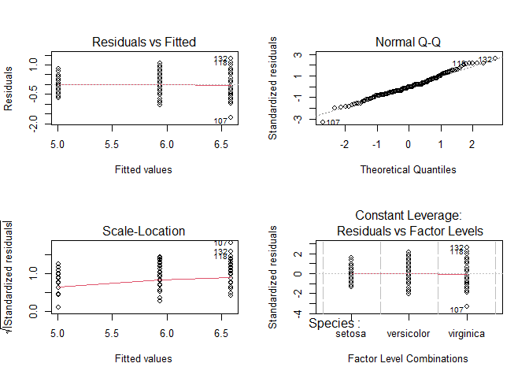

```r
par(mfrow = c(2,2))
plot(iris_anova)
```

If assumptions are met, check the p-value using the *summary* or *Anova* function.

```r
summary(iris_anova)
```

```
##
## Call:
## lm(formula = Sepal.Length ~ Species, data = iris)
##
## Residuals:
##     Min      1Q  Median      3Q     Max
## -1.6880 -0.3285 -0.0060  0.3120  1.3120
##
## Coefficients:
##                   Estimate Std. Error t value Pr(>|t|)
## (Intercept)         5.0060     0.0728  68.762  < 2e-16 ***
## Speciesversicolor   0.9300     0.1030   9.033 8.77e-16 ***
## Speciesvirginica    1.5820     0.1030  15.366  < 2e-16 ***
## ---
## Signif. codes:  0 '***' 0.001 '**' 0.01 '*' 0.05 '.' 0.1 ' ' 1
##
## Residual standard error: 0.5148 on 147 degrees of freedom
## Multiple R-squared:  0.6187, Adjusted R-squared:  0.6135
## F-statistic: 119.3 on 2 and 147 DF,  p-value: < 2.2e-16
```

```r
library(car)
Anova(iris_anova, type = "III")
```

```
## Anova Table (Type III tests)
##
## Response: Sepal.Length
##              Sum Sq  Df F value    Pr(>F)
## (Intercept) 1253.00   1 4728.16 < 2.2e-16 ***
## Species       63.21   2  119.26 < 2.2e-16 ***
## Residuals     38.96 147
## ---
## Signif. codes:  0 '***' 0.001 '**' 0.01 '*' 0.05 '.' 0.1 ' ' 1
```

If the overall test is significant, carry out post hoc tests (Tukey shown here for all pairs, as most common)

```r
library(multcomp)
compare_cont_tukey <- glht(iris_anova, linfct = mcp(Species = "Tukey"))
summary(compare_cont_tukey)
```

```
##
##   Simultaneous Tests for General Linear Hypotheses
##
## Multiple Comparisons of Means: Tukey Contrasts
##
##
## Fit: lm(formula = Sepal.Length ~ Species, data = iris)
##
## Linear Hypotheses:
##                             Estimate Std. Error t value Pr(>|t|)
## versicolor - setosa == 0       0.930      0.103   9.033   <1e-07 ***
## virginica - setosa == 0        1.582      0.103  15.366   <1e-07 ***
## virginica - versicolor == 0    0.652      0.103   6.333   <1e-07 ***
## ---
## Signif. codes:  0 '***' 0.001 '**' 0.01 '*' 0.05 '.' 0.1 ' ' 1
## (Adjusted p values reported -- single-step method)
```

If assumptions are not met, we can use the Kruskal Wallis non-parametric test and associated post hoc tests.

```r
kruskal.test(Sepal.Length ~ Species, data = iris)
```

```
##
##  Kruskal-Wallis rank sum test
##
## data:  Sepal.Length by Species
## Kruskal-Wallis chi-squared = 96.937, df = 2, p-value < 2.2e-16
```

```r
pairwise.wilcox.test(iris$Sepal.Length,
                          iris$Species,
                          p.adjust.method="holm")
```

```
##
##  Pairwise comparisons using Wilcoxon rank sum test with continuity correction
##
## data:  iris$Sepal.Length and iris$Species
##
##            setosa  versicolor
## versicolor 1.7e-13 -
## virginica  < 2e-16 5.9e-07
##
## P value adjustment method: holm
```

or a bootstrap alternative

```r
library(WRS2)
t1waybt(Sepal.Length~Species, iris)
```

```
## Call:
## t1waybt(formula = Sepal.Length ~ Species, data = iris)
##
## Effective number of bootstrap samples was 599.
##
## Test statistic: 111.9502
## p-value: 0
## Variance explained: 0.716
## Effect size: 0.846
```

```r
bootstrap_post_hoc <- mcppb20(Sepal.Length~Species, iris)
p.adjust(as.numeric(bootstrap_post_hoc$comp[,6]), "holm")
```

```
## [1] 0 0 0
```

## Just for practice

*Do this problems using ANOVA, Kruskal-Wallis, and bootstrapping methods. Make sure you can plot the data and carry out multiple comparison methods as needed. Also be sure to understand the use of coefficients and adjusted R<sup>2</sup> values and where to find them.*

### 1

1. Use the iris dataset in R to determine if petal length differs among species.

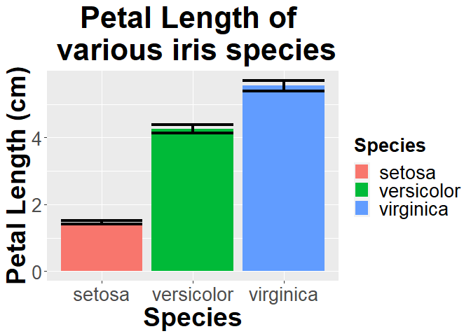

```r
#plot
library(Rmisc)
function_output <- summarySE(iris, measurevar="Petal.Length", groupvars =
                               c("Species"))
library(ggplot2)
ggplot(function_output, aes(x=Species, y=Petal.Length)) +
  geom_col(aes(fill=Species), size = 3) +
  geom_errorbar(aes(ymin=Petal.Length-ci, ymax=Petal.Length+ci), size=1.5) +
  ylab("Petal Length (cm)")+ggtitle("Petal Length of \n various iris species")+
  theme(axis.title.x = element_text(face="bold", size=28),
        axis.title.y = element_text(face="bold", size=28),
        axis.text.y  = element_text(size=20),
        axis.text.x  = element_text(size=20),
        legend.text =element_text(size=20),
        legend.title = element_text(size=20, face="bold"),
        plot.title = element_text(hjust = 0.5, face="bold", size=32))
```

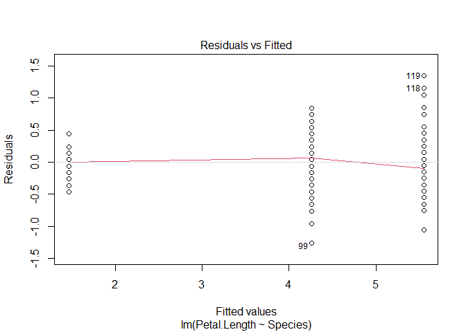

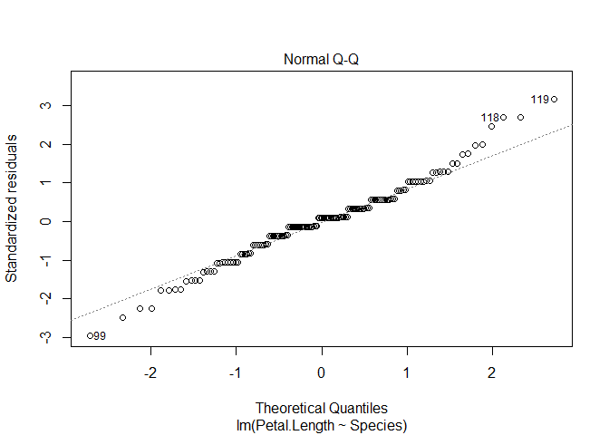

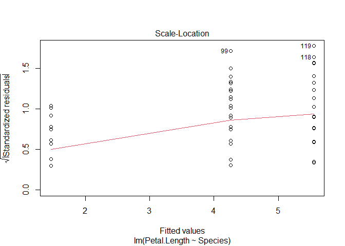

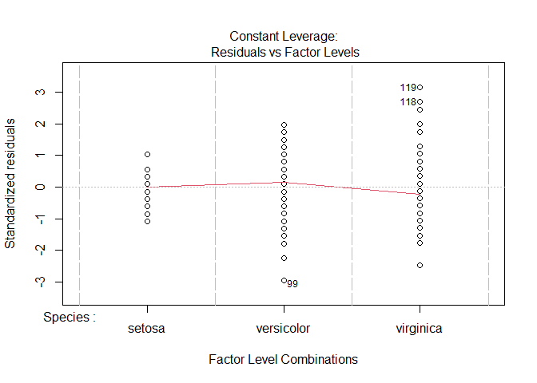

```r
petal <- lm(Petal.Length ~ Species, iris)
plot(petal)
```

```r
library(car)
Anova(petal, type = "III")
```

```
## Anova Table (Type III tests)
##
## Response: Petal.Length
##             Sum Sq  Df F value    Pr(>F)
## (Intercept) 106.87   1   577.1 < 2.2e-16 ***
## Species     437.10   2  1180.2 < 2.2e-16 ***
## Residuals    27.22 147
## ---
## Signif. codes:  0 '***' 0.001 '**' 0.01 '*' 0.05 '.' 0.1 ' ' 1
```

```r
#compare to
summary(petal)
```

```
##
## Call:
## lm(formula = Petal.Length ~ Species, data = iris)
##
## Residuals:
##    Min     1Q Median     3Q    Max
## -1.260 -0.258  0.038  0.240  1.348
##
## Coefficients:
##                   Estimate Std. Error t value Pr(>|t|)
## (Intercept)        1.46200    0.06086   24.02   <2e-16 ***
## Speciesversicolor  2.79800    0.08607   32.51   <2e-16 ***
## Speciesvirginica   4.09000    0.08607   47.52   <2e-16 ***
## ---
## Signif. codes:  0 '***' 0.001 '**' 0.01 '*' 0.05 '.' 0.1 ' ' 1
##
## Residual standard error: 0.4303 on 147 degrees of freedom
## Multiple R-squared:  0.9414, Adjusted R-squared:  0.9406
## F-statistic:  1180 on 2 and 147 DF,  p-value: < 2.2e-16
```

```r
library(multcomp)
comp_cholest <- glht(petal, linfct = mcp(Species = "Tukey"))
summary(comp_cholest)
```

```
##
##   Simultaneous Tests for General Linear Hypotheses
##
## Multiple Comparisons of Means: Tukey Contrasts
##
##
## Fit: lm(formula = Petal.Length ~ Species, data = iris)
##
## Linear Hypotheses:
##                             Estimate Std. Error t value Pr(>|t|)
## versicolor - setosa == 0     2.79800    0.08607   32.51   <2e-16 ***
## virginica - setosa == 0      4.09000    0.08607   47.52   <2e-16 ***
## virginica - versicolor == 0  1.29200    0.08607   15.01   <2e-16 ***
## ---
## Signif. codes:  0 '***' 0.001 '**' 0.01 '*' 0.05 '.' 0.1 ' ' 1
## (Adjusted p values reported -- single-step method)
```

```r
#kw approach
petal <- kruskal.test(Petal.Length ~ Species, iris)
pairwise.wilcox.test(iris$Sepal.Length,
                          iris$Species,
                          p.adjust.method="holm")
```

```
##
##  Pairwise comparisons using Wilcoxon rank sum test with continuity correction
##
## data:  iris$Sepal.Length and iris$Species
##
##            setosa  versicolor
## versicolor 1.7e-13 -
## virginica  < 2e-16 5.9e-07
##
## P value adjustment method: holm
```

```r
#bootstrap
library(WRS2)
t1waybt(Petal.Length~Species, iris)
```

```
## Call:
## t1waybt(formula = Petal.Length ~ Species, data = iris)
##
## Effective number of bootstrap samples was 599.
##
## Test statistic: 1510.684
## p-value: 0
## Variance explained: 0.71
## Effect size: 0.843
```

```r
bootstrap_post_hoc <- mcppb20(Petal.Length~Species, iris)
#use p.adjust to correct for FWER
p.adjust(as.numeric(bootstrap_post_hoc$comp[,6]), "holm")
```

```
## [1] 0 0 0
```

*Answer: We used an ANOVA (a special case of linear models) to investigate how a numerical response variable differed among 3 groups. This was appropriate as evidenced by the residual plots (there is no pattern in the residuals and they are normally distributed), but other methods are demonstrated as well.

Using an ANOVA, we found F<sub>2,147</sub>= 1180.2, which led to a p-value of <.001. Given this, I reject the null hypothesis there is no difference among mean measurements for each species.  
Post-hoc testing indicated all species significantly differed from all others (all p <.05) using a Tukey approach to control for family-wise error rate. Kruskal-Wallis and bootstrapping approaches led to similar conclusions.*

### 2

2. Data on plant heights (in cm) for plants grown with a new and old formulation of fertilizer can be found at

https://docs.google.com/spreadsheets/d/e/2PACX-1vSUVowOKlmTic4ekL7LSbwDcqrsDSXv5K_c4Qyfcvz1lLE1_iINmGzy0zMGxY7z5DImlUErK4S2wY7Y/pub?gid=0&single=true&output=csv.

Analyze this data using the t.test function and the lm function to convince yourself that t-tests are special cases of ANOVAs, which are special cases of linear models!

```r
fertilizer <- read.csv("https://docs.google.com/spreadsheets/d/e/2PACX-1vSUVowOKlmTic4ekL7LSbwDcqrsDSXv5K_c4Qyfcvz1lLE1_iINmGzy0zMGxY7z5DImlUErK4S2wY7Y/pub?gid=0&single=true&output=csv",
                       stringsAsFactors = T)
#note use of var.equal!  assumption of ANOVAs
t.test(height ~ fertilizer, fertilizer, var.equal = T)
```

```
##
##  Two Sample t-test
##
## data:  height by fertilizer
## t = 2.9884, df = 16, p-value = 0.008686
## alternative hypothesis: true difference in means between group new and group old is not equal to 0
## 95 percent confidence interval:
##  1.34853 7.93147
## sample estimates:
## mean in group new mean in group old
##             56.55             51.91
```

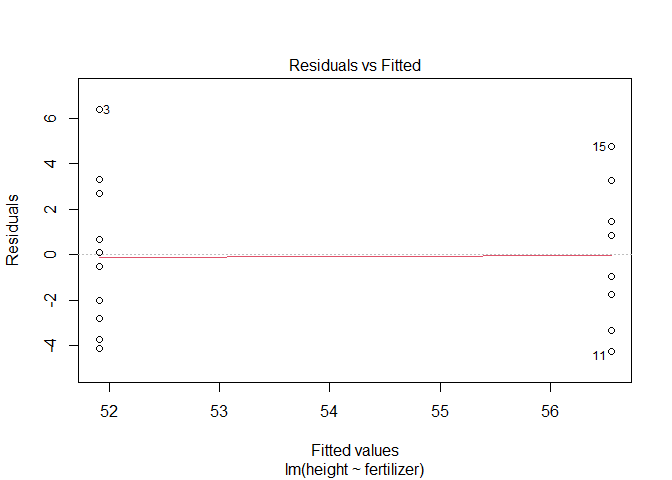

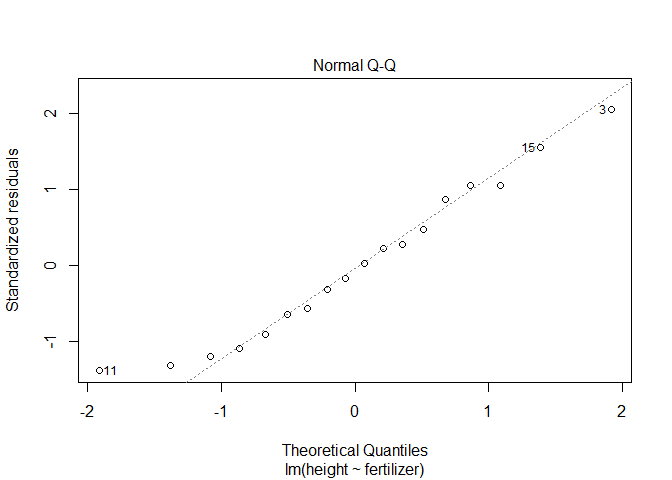

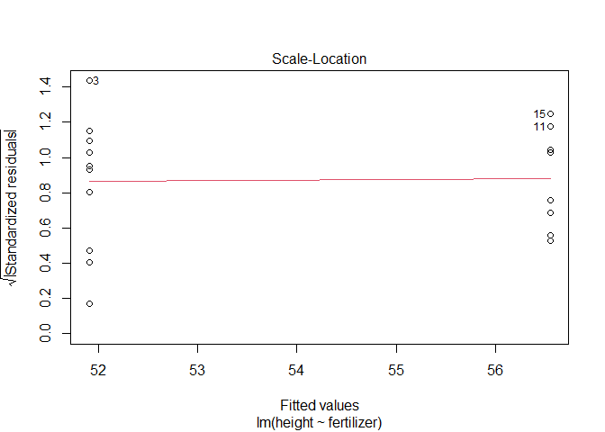

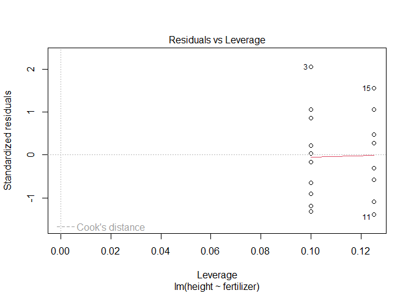

```r
fert_lm <- lm(height ~ fertilizer, fertilizer)
plot(fert_lm)
```

```r
summary(fert_lm)
```

```
##
## Call:
## lm(formula = height ~ fertilizer, data = fertilizer)
##
## Residuals:
##    Min     1Q Median     3Q    Max
##  -4.25  -2.61  -0.21   2.38   6.39
##
## Coefficients:
##               Estimate Std. Error t value Pr(>|t|)
## (Intercept)     56.550      1.157  48.865  < 2e-16 ***
## fertilizerold   -4.640      1.553  -2.988  0.00869 **
## ---
## Signif. codes:  0 '***' 0.001 '**' 0.01 '*' 0.05 '.' 0.1 ' ' 1
##
## Residual standard error: 3.273 on 16 degrees of freedom
## Multiple R-squared:  0.3582, Adjusted R-squared:  0.3181
## F-statistic: 8.931 on 1 and 16 DF,  p-value: 0.008686
```

```r
require(car)
Anova(fert_lm, type = "III")
```

```
## Anova Table (Type III tests)
##
## Response: height
##              Sum Sq Df   F value    Pr(>F)
## (Intercept) 25583.2  1 2387.7612 < 2.2e-16 ***
## fertilizer     95.7  1    8.9308  0.008686 **
## Residuals     171.4 16
## ---
## Signif. codes:  0 '***' 0.001 '**' 0.01 '*' 0.05 '.' 0.1 ' ' 1
```

*Answer: t-tests and ANOVA (lm) approaches yield the same results. Note for the tests to match exactly we have to assume equal variances among groups for the t-tests. In both we reject the null hypothesis of no difference among mean height of plants based on fertilizer. Notice the t statistic (2.9884) is the square root of the F statistic (8.931). The t distribution corresponds to the F with only 1 df in the numerator (so its not listed!).*

## For the following questions, pick the appropriate method for analyzing the question. Use a plot of the data and/or model analysis to justify your decision. Make sure you can carry out multiple comparison methods as needed. Also be sure to understand the use of coefficients and adjusted R<sup>2</sup> values and where to find them.

### 3

3. Data on sugar cane yield for multiple fields is available using

read.table(“https://docs.google.com/spreadsheets/d/e/2PACX-1vRjstKreIM6UknyKFQCtw2_Q6itY9iOAVWO1hUNZkBFL8mwVssvTevqgzV22YDKCUeJq0HBDrsBrf5O/pub?gid=971470377&single=true&output=tsv”, header = T, stringsAsFactors = T)

More info on the data can be found at http://www.statsci.org/data/oz/cane.html. Is there evidence that location (DistrictPosition column) impacts yield (Tonn.Hect column)? If so, which areas are driving this distance?

```r
cane <- read.table("https://docs.google.com/spreadsheets/d/e/2PACX-1vRjstKreIM6UknyKFQCtw2_Q6itY9iOAVWO1hUNZkBFL8mwVssvTevqgzV22YDKCUeJq0HBDrsBrf5O/pub?gid=971470377&single=true&output=tsv", header = T, stringsAsFactors = T)
summary(cane)
```

```
##            District                     DistrictGroup  DistrictPosition
##  WrightsCreek  : 389   BahanaSouth             : 498   C: 498
##  Highleigh     : 360   Cairns/Mulgrave(dry)    :1517   E: 482
##  PineCreek     : 317   Cairns/Mulgrave(Med-wet): 842   N: 452
##  LittleMulgrave: 308   MulgravetoBahana        : 466   S: 553
##  Aloomba       : 284   NorthCairns             : 452   W:1790
##  Hambledon     : 267
##  (Other)       :1850
##      SoilID           SoilName         Area           Variety        Ratoon
##  Min.   :442.0   Liverpool: 737   Min.   : 0.020   138    :629   1R     :767
##  1st Qu.:712.0   Mission  : 399   1st Qu.: 0.880   120    :598   2R     :760
##  Median :801.0   Innisfail: 330   Median : 1.940   152    :513   3R     :692
##  Mean   :757.5   Virgil   : 272   Mean   : 2.578   124    :466   4R     :493
##  3rd Qu.:816.0   Thorpe   : 237   3rd Qu.: 3.620   113    :358   PL     :360
##  Max.   :838.0   Edmonton : 220   Max.   :38.270   117    :319   RP     :304
##                  (Other)  :1580                    (Other):892   (Other):399
##       Age         HarvestMonth  HarvestDuration     Tonn.Hect
##  Min.   :0.000   Min.   : 6.0   Min.   :  0.000   Min.   :   1.45
##  1st Qu.:1.000   1st Qu.: 7.0   1st Qu.:  0.000   1st Qu.:  75.54
##  Median :2.000   Median : 9.0   Median :  1.000   Median : 173.46
##  Mean   :2.151   Mean   : 8.6   Mean   :  9.175   Mean   : 240.11
##  3rd Qu.:3.000   3rd Qu.:10.0   3rd Qu.:  3.000   3rd Qu.: 336.40
##  Max.   :8.000   Max.   :11.0   Max.   :155.000   Max.   :1954.01
##
##      Fibre           Sugar           Jul.96          Aug.96
##  Min.   :14.20   Min.   : 6.08   Min.   :  0.0   Min.   : 2.200
##  1st Qu.:15.38   1st Qu.:10.93   1st Qu.: 42.2   1st Qu.: 4.500
##  Median :15.80   Median :11.84   Median : 46.0   Median : 7.100
##  Mean   :15.87   Mean   :11.82   Mean   : 50.9   Mean   : 9.274
##  3rd Qu.:16.25   3rd Qu.:12.73   3rd Qu.: 61.0   3rd Qu.: 9.900
##  Max.   :19.10   Max.   :17.36   Max.   :141.5   Max.   :36.000
##
##      Sep.96           Oct.96          Nov.96           Dec.96
##  Min.   : 0.000   Min.   :137.5   Min.   :  6.00   Min.   :128.5
##  1st Qu.: 0.000   1st Qu.:181.8   1st Qu.: 17.60   1st Qu.:161.9
##  Median : 5.000   Median :224.8   Median : 31.00   Median :239.5
##  Mean   : 5.932   Mean   :219.8   Mean   : 40.39   Mean   :223.6
##  3rd Qu.:11.200   3rd Qu.:240.3   3rd Qu.: 39.50   3rd Qu.:241.4
##  Max.   :14.000   Max.   :308.0   Max.   :100.60   Max.   :353.5
##
```

[output cut: 9 more lines]

```
##  Min.   : 30.00   Min.   : 34.20   Min.   :  8.60   Min.   : 18.80
##  1st Qu.: 44.60   1st Qu.: 40.20   1st Qu.: 16.40   1st Qu.: 39.20
##  Median : 63.50   Median : 41.00   Median : 24.00   Median : 68.00
##  Mean   : 89.99   Mean   : 82.62   Mean   : 31.65   Mean   : 70.47
##  3rd Qu.: 72.60   3rd Qu.:113.80   3rd Qu.: 28.00   3rd Qu.:112.50
##  Max.   :220.00   Max.   :202.00   Max.   :109.00   Max.   :117.50
##
##      Sep.97           Oct.97           Nov.97          Dec.97
##  Min.   :  4.00   Min.   :  2.00   Min.   : 13.5   Min.   : 75.0
##  1st Qu.: 42.80   1st Qu.: 22.20   1st Qu.: 62.0   1st Qu.:223.0
##  Median : 73.00   Median : 38.10   Median :123.7   Median :278.3
##  Mean   : 70.46   Mean   : 55.53   Mean   :114.3   Mean   :264.4
##  3rd Qu.:106.00   3rd Qu.: 53.10   3rd Qu.:167.4   3rd Qu.:315.2
##  Max.   :109.20   Max.   :216.50   Max.   :198.0   Max.   :336.6
##
```

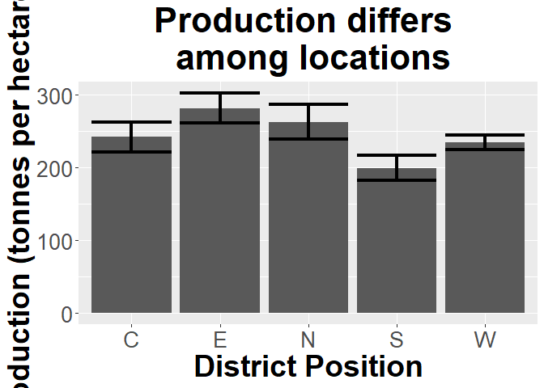

```r
cane_summary <- summarySE(cane, measurevar="Tonn.Hect", groupvars =
                               c("DistrictPosition"))

ggplot(cane_summary, aes(x=DistrictPosition, y=Tonn.Hect)) +
  geom_col(size = 3) +
  geom_errorbar(aes(ymin=Tonn.Hect-ci, ymax=Tonn.Hect+ci), size=1.5) +
  ylab("Production (tonnes per hectare)") +
  xlab("District Position") +
  ggtitle("Production differs \n among locations") +
  theme(axis.title.x = element_text(face="bold", size=28),
        axis.title.y = element_text(face="bold", size=28),
        axis.text.y  = element_text(size=20),
        axis.text.x  = element_text(size=20),
        legend.text =element_text(size=20),
        legend.title = element_text(size=20, face="bold"),
        plot.title = element_text(hjust = 0.5, face="bold", size=32))
```

```r
impact_district <- lm(Tonn.Hect ~ DistrictPosition, cane)
summary(impact_district)
```

```
##
## Call:
## lm(formula = Tonn.Hect ~ DistrictPosition, data = cane)
##
## Residuals:
##     Min      1Q  Median      3Q     Max
## -274.41 -159.66  -66.07   90.26 1754.55
##
## Coefficients:
##                   Estimate Std. Error t value Pr(>|t|)
## (Intercept)        242.418      9.993  24.259  < 2e-16 ***
## DistrictPositionE   39.360     14.249   2.762  0.00577 **
## DistrictPositionN   20.252     14.487   1.398  0.16222
## DistrictPositionS  -42.955     13.777  -3.118  0.00183 **
## DistrictPositionW   -7.317     11.298  -0.648  0.51727
## ---
## Signif. codes:  0 '***' 0.001 '**' 0.01 '*' 0.05 '.' 0.1 ' ' 1
##
## Residual standard error: 223 on 3770 degrees of freedom
## Multiple R-squared:  0.0107, Adjusted R-squared:  0.009652
## F-statistic:  10.2 on 4 and 3770 DF,  p-value: 3.293e-08
```

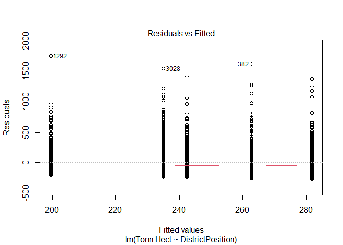

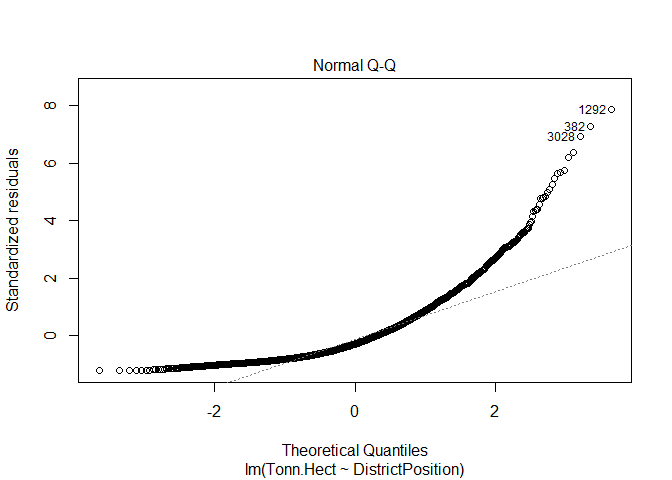

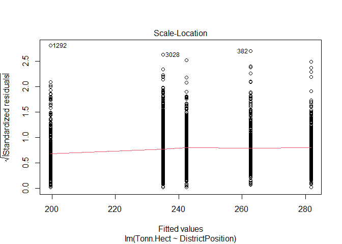

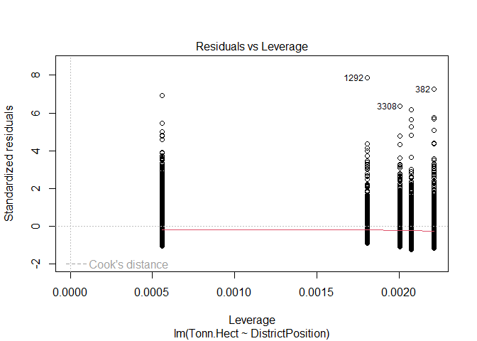

```r
plot(impact_district)#not really normal...lets bootstrap
```

```r
require(WRS2)
t1waybt(Tonn.Hect ~ DistrictPosition, cane)
```

```
## Call:
## t1waybt(formula = Tonn.Hect ~ DistrictPosition, data = cane)
##
## Effective number of bootstrap samples was 599.
##
## Test statistic: 16.5244
## p-value: 0
## Variance explained: 0.032
## Effect size: 0.178
```

```r
mcppb20(Tonn.Hect ~ DistrictPosition, cane)
```

```
## Call:
## mcppb20(formula = Tonn.Hect ~ DistrictPosition, data = cane)
##
##            psihat  ci.lower  ci.upper p-value
## S vs. N -56.10126 -93.94768 -12.57711 0.00000
## S vs. E -12.51609 -52.37775  27.67806 0.34057
## S vs. W  39.25821   8.37904  71.99426 0.00000
## S vs. C  -0.97532 -30.05251  28.53101 0.88147
## N vs. E  43.58517   9.05074  81.71705 0.00334
## N vs. W  95.35948  53.33972 130.29656 0.00000
## N vs. C  55.12595  24.18439  86.83790 0.00000
## E vs. W  51.77430  23.58505  85.86302 0.00000
## E vs. C  11.54077 -14.41774  41.55552 0.24040
## W vs. C -40.23353 -59.62852 -17.87071 0.00000
```

```r
p <- mcppb20(Tonn.Hect ~ DistrictPosition, cane)
p.adjust(as.numeric(p$comp[,6]), "holm")
```

```
##  [1] 0.00000000 0.95158598 0.00000000 0.95158598 0.02671119 0.00000000
##  [7] 0.00000000 0.00000000 0.95158598 0.00000000
```

```r
#compare to lm apporach
require(car)
Anova(impact_district, type = "III")
```

```
## Anova Table (Type III tests)
##
## Response: Tonn.Hect
##                     Sum Sq   Df F value    Pr(>F)
## (Intercept)       29265733    1 588.476 < 2.2e-16 ***
## DistrictPosition   2028140    4  10.195 3.293e-08 ***
## Residuals        187487281 3770
## ---
## Signif. codes:  0 '***' 0.001 '**' 0.01 '*' 0.05 '.' 0.1 ' ' 1
```

```r
require(multcomp)
comp_district <- glht(impact_district, linfct = mcp(DistrictPosition = "Tukey"))
summary(comp_district)
```

```
##
##   Simultaneous Tests for General Linear Hypotheses
##
## Multiple Comparisons of Means: Tukey Contrasts
##
##
## Fit: lm(formula = Tonn.Hect ~ DistrictPosition, data = cane)
##
## Linear Hypotheses:
##            Estimate Std. Error t value Pr(>|t|)
## E - C == 0   39.360     14.249   2.762  0.04403 *
## N - C == 0   20.252     14.487   1.398  0.62080
## S - C == 0  -42.955     13.777  -3.118  0.01530 *
## W - C == 0   -7.317     11.298  -0.648  0.96582
## N - E == 0  -19.108     14.601  -1.309  0.67820
## S - E == 0  -82.315     13.896  -5.924  < 0.001 ***
## W - E == 0  -46.677     11.444  -4.079  < 0.001 ***
## S - N == 0  -63.207     14.141  -4.470  < 0.001 ***
## W - N == 0  -27.569     11.739  -2.348  0.12589
## W - S == 0   35.638     10.850   3.285  0.00884 **
## ---
## Signif. codes:  0 '***' 0.001 '**' 0.01 '*' 0.05 '.' 0.1 ' ' 1
## (Adjusted p values reported -- single-step method)
```

Answer: For this analysis I used a bootstrap approach as the residual plots suggested a non-normal distribution. Analysis revealed a test statistics of 16.52 and p-value of 0, so I reject the null hypothesis of no difference among Districts. since I rejected the null hypothesis, I have to use post-hoc tsts to determine which groups are different than the others.  
Post-hoc tests reveal all district areas differ from each other except for south and east, south and central, and east and central (using sequential FDR to control for family-wise error rate.)

*Note that a linear model does lead to slightly different findings regarding which districts differ from which others.*

### 4

4. Data on FEV (forced expiratory volume), a measure of lung function, can be found at

http://www.statsci.org/data/general/fev.txt

More information on the dataset is available at

http://www.statsci.org/data/general/fev.html.

Is there evidence that FEV depends on gender? If so, which gender has the higher FEV score? How much variance does gender explain?

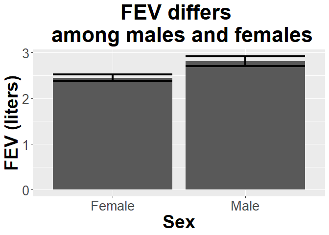

```r
fev <- read.table("http://www.statsci.org/data/general/fev.txt", header = T,
                  stringsAsFactors = T)
fev_summary <- summarySE(fev, measurevar="FEV", groupvars =
                               c("Sex"))

ggplot(fev_summary, aes(x=Sex, y=FEV)) +
  geom_col(size = 3) +
  geom_errorbar(aes(ymin=FEV-ci, ymax=FEV+ci), size=1.5) +
  ylab("FEV (liters)") +
  xlab("Sex") +
  ggtitle("FEV differs \n among males and females") +
  theme(axis.title.x = element_text(face="bold", size=28),
        axis.title.y = element_text(face="bold", size=28),
        axis.text.y  = element_text(size=20),
        axis.text.x  = element_text(size=20),
        legend.text =element_text(size=20),
        legend.title = element_text(size=20, face="bold"),
        plot.title = element_text(hjust = 0.5, face="bold", size=32))
```

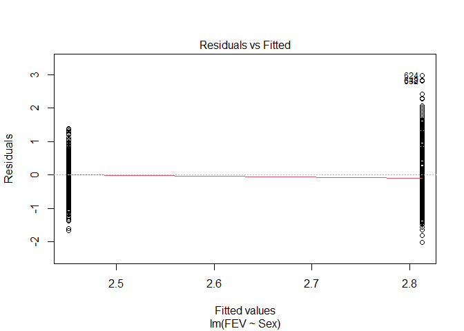

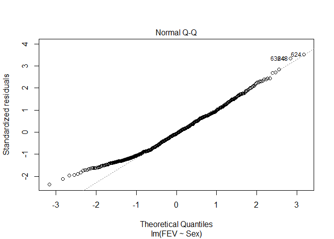

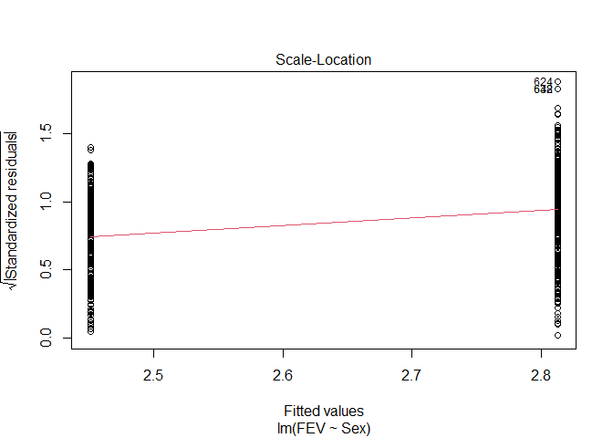

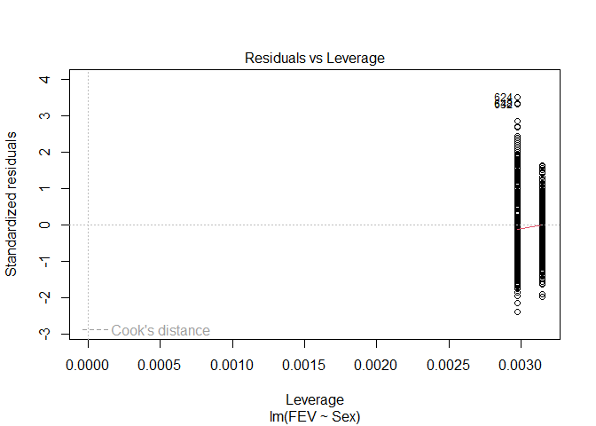

```r
fev_gender <- lm(FEV ~ Sex, fev)
plot(fev_gender) #anova is fine
```

```r
Anova(fev_gender, type = "III")
```

```
## Anova Table (Type III tests)
##
## Response: FEV
##              Sum Sq  Df  F value    Pr(>F)
## (Intercept) 1910.62   1 2652.756 < 2.2e-16 ***
## Sex           21.32   1   29.607 7.496e-08 ***
## Residuals    469.60 652
## ---
## Signif. codes:  0 '***' 0.001 '**' 0.01 '*' 0.05 '.' 0.1 ' ' 1
```

```r
summary(fev_gender)
```

```
##
## Call:
## lm(formula = FEV ~ Sex, data = fev)
##
## Residuals:
##      Min       1Q   Median       3Q      Max
## -2.01645 -0.69420 -0.06367  0.58233  2.98055
##
## Coefficients:
##             Estimate Std. Error t value Pr(>|t|)
## (Intercept)  2.45117    0.04759  51.505  < 2e-16 ***
## SexMale      0.36128    0.06640   5.441  7.5e-08 ***
## ---
## Signif. codes:  0 '***' 0.001 '**' 0.01 '*' 0.05 '.' 0.1 ' ' 1
##
## Residual standard error: 0.8487 on 652 degrees of freedom
## Multiple R-squared:  0.04344,    Adjusted R-squared:  0.04197
## F-statistic: 29.61 on 1 and 652 DF,  p-value: 7.496e-08
```

I used an ANOVA (or linear model, or t-test, here, all the same since 2 groups!) to consider the impact of sex on FEV. This was appropriate as evidenced by the residual plots (there is no pattern in the residuals and they are normally distributed). Results indicate there is a difference among sexes (F<sub>1,652</sub> = 29.607, p<.001). There is no need for post-hoc tests here since there are only 2 groups being considered.  
Coefficients related to the groups (note female is replaced by intercept here, and the SexMale coefficient is relative to that) indicates that males have a higher FEV on average. Graphs also show this relationship.

### 5

5. A professor carried out a long-term study to see how various factors impacted pulse rate before and after exercise. Data can be found at

http://www.statsci.org/data/oz/ms212.txt

With more info at

http://www.statsci.org/data/oz/ms212.html.

Is there evidence that frequency of exercise (Exercise column) impacts resting pulse rate (Pulse1 column)?

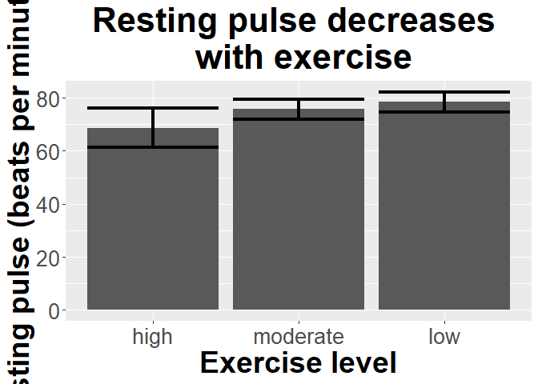

```r
pulse <- read.table("http://www.statsci.org/data/oz/ms212.txt", header = T,
                    stringsAsFactors = T)
pulse$Exercise <- factor(pulse$Exercise)
library(plyr)
pulse$Exercise <- revalue(pulse$Exercise, c("1" = "high",
                                            "2" = "moderate",
                                            "3" = "low"))

exercise_summary <- summarySE(pulse, measurevar="Pulse1", groupvars =
                               c("Exercise"), na.rm = T)

ggplot(exercise_summary, aes(x=Exercise, y=Pulse1)) +
  geom_col(size = 3) +
  geom_errorbar(aes(ymin=Pulse1-ci, ymax=Pulse1+ci), size=1.5) +
  ylab("Resting pulse (beats per minute)") +
  xlab("Exercise level")+
  ggtitle("Resting pulse decreases \n with exercise") +
  theme(axis.title.x = element_text(face="bold", size=28),
        axis.title.y = element_text(face="bold", size=28),
        axis.text.y  = element_text(size=20),
        axis.text.x  = element_text(size=20),
        legend.text =element_text(size=20),
        legend.title = element_text(size=20, face="bold"),
        plot.title = element_text(hjust = 0.5, face="bold", size=32))
```

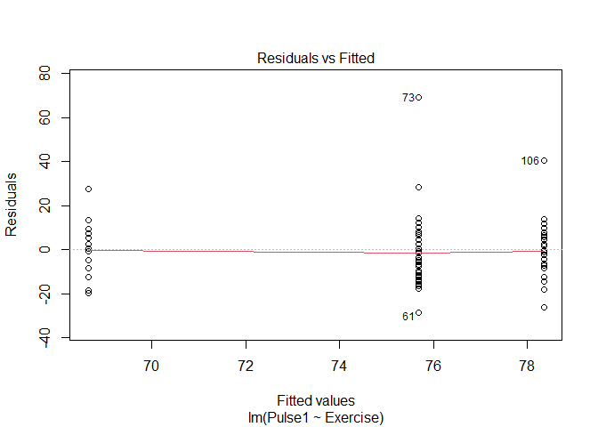

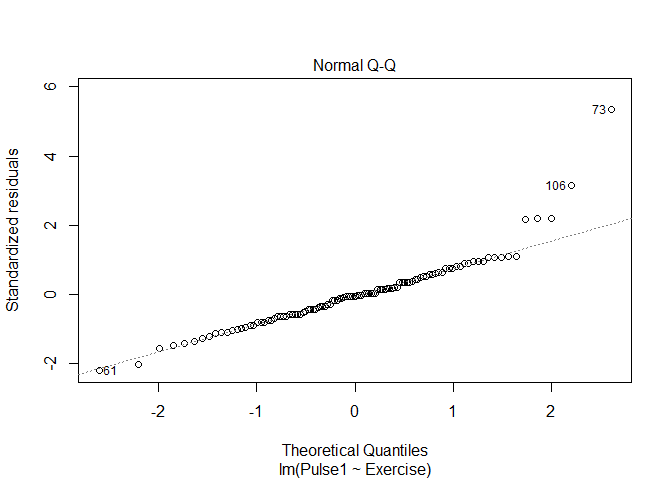

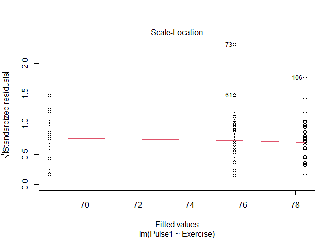

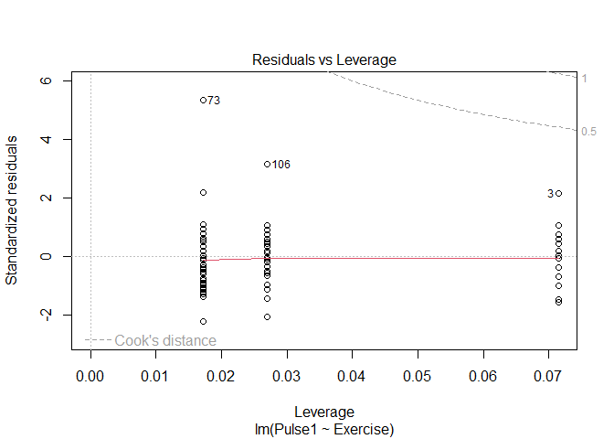

```r
initial <- lm(Pulse1 ~ Exercise, pulse)
plot(initial)
```

```r
summary(initial)
```

```
##
## Call:
## lm(formula = Pulse1 ~ Exercise, data = pulse)
##
## Residuals:
##     Min      1Q  Median      3Q     Max
## -28.690  -7.690  -0.643   6.310  69.310
##
## Coefficients:
##                  Estimate Std. Error t value Pr(>|t|)
## (Intercept)        68.643      3.496  19.633   <2e-16 ***
## Exercisemoderate    7.047      3.895   1.809   0.0733 .
## Exerciselow         9.708      4.105   2.365   0.0198 *
## ---
## Signif. codes:  0 '***' 0.001 '**' 0.01 '*' 0.05 '.' 0.1 ' ' 1
##
## Residual standard error: 13.08 on 106 degrees of freedom
##   (1 observation deleted due to missingness)
## Multiple R-squared:  0.05013,    Adjusted R-squared:  0.03221
## F-statistic: 2.797 on 2 and 106 DF,  p-value: 0.0655
```

```r
Anova(initial, type = "III")
```

```
## Anova Table (Type III tests)
##
## Response: Pulse1
##             Sum Sq  Df  F value Pr(>F)
## (Intercept)  65966   1 385.4658 <2e-16 ***
## Exercise       957   2   2.7971 0.0655 .
## Residuals    18140 106
## ---
## Signif. codes:  0 '***' 0.001 '**' 0.01 '*' 0.05 '.' 0.1 ' ' 1
```

*I used a linear model to test for difference in mean resting pulse rates based on group. This was appropriate as evidenced by the residual plots (there is no pattern in the residuals and they are normally distributed). Analyses suggest there is no difference in resting pulse rate among groups (F<sub>2,106</sub> = 2.8, p = .07), so I fail to reject the null hypothesis that a difference does not exist in mean resting pulse rate based on groups. The alternative hypothesis is that a difference does exist in mean resting pulse rate based on groups.*

### 6

6. Continuing with the pulse dataset, is there evidence frequency of exercise impacts change in pulse rate? Note we should only consider change for students who ran between the first and second pulse measures (Ran column = 1).

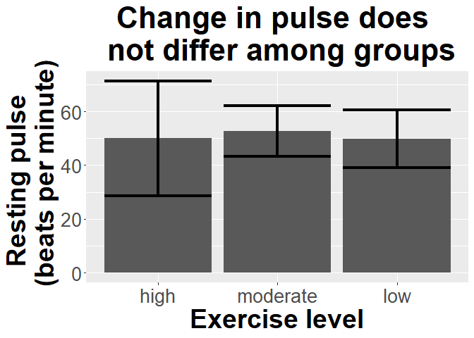

```r
pulse$change <- pulse$Pulse2 - pulse$Pulse1

change_summary <- summarySE(pulse[pulse$Ran == 1, ], measurevar="change", groupvars =
                               c("Exercise"), na.rm = T)

ggplot(change_summary, aes(x=Exercise, y=change)) +
  geom_col(size = 3) +
  geom_errorbar(aes(ymin=change-ci, ymax=change+ci), size=1.5) +
  ylab("Resting pulse \n (beats per minute)") +
  xlab("Exercise level")+
  ggtitle("Change in pulse does \n not differ among groups") +
  theme(axis.title.x = element_text(face="bold", size=28),
        axis.title.y = element_text(face="bold", size=28),
        axis.text.y  = element_text(size=20),
        axis.text.x  = element_text(size=20),
        legend.text =element_text(size=20),
        legend.title = element_text(size=20, face="bold"),
        plot.title = element_text(hjust = 0.5, face="bold", size=32))
```

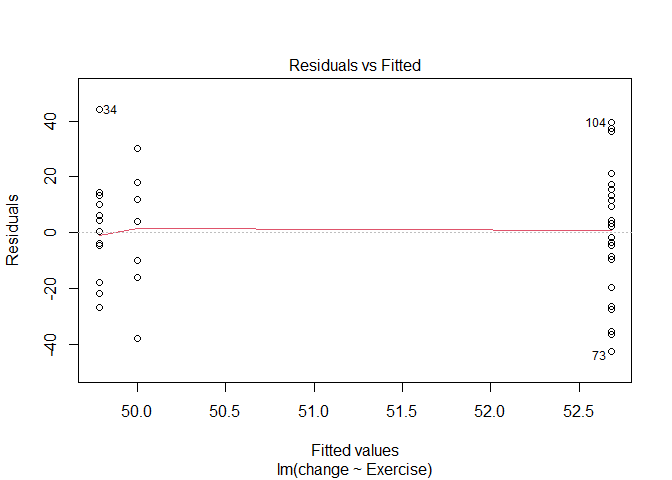

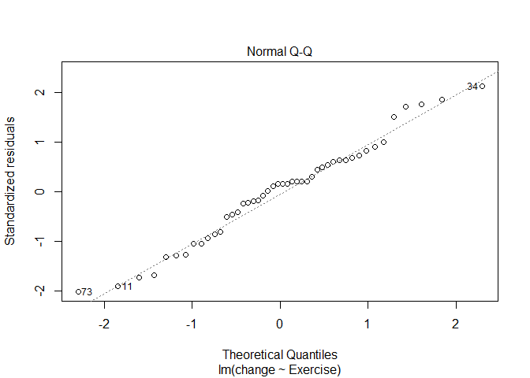

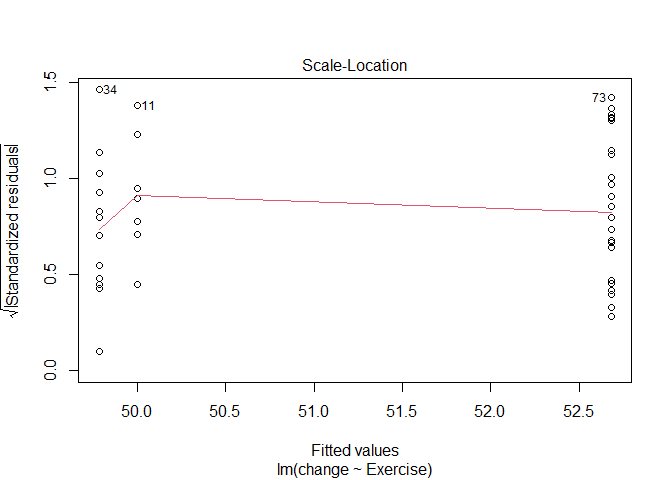

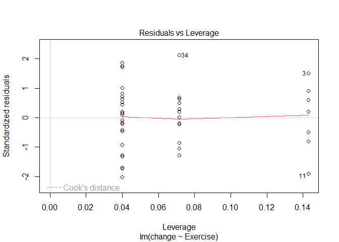

```r
change <- lm(change ~ Exercise, pulse[pulse$Ran == 1, ])
plot(change)
```

```r
Anova(change, type = "III")
```

```
## Anova Table (Type III tests)
##
## Response: change
##              Sum Sq Df F value    Pr(>F)
## (Intercept) 17500.0  1 37.7689 2.245e-07 ***
## Exercise       91.2  2  0.0984    0.9065
## Residuals   19923.8 43
## ---
## Signif. codes:  0 '***' 0.001 '**' 0.01 '*' 0.05 '.' 0.1 ' ' 1
```

*I used a linear model to test for difference in change in pulse rates (before and after running) based on group. This was appropriate as evidenced by the residual plots (there is no pattern in the residuals and they are normally distributed). Analyses suggest there is no difference in resting pulse rate among groups (F<sub>2,43</sub> = .09, p = .90), so I fail to reject the null hypothesis that a difference does not exist in change in pulse rates (before and after running) based on group. The alternative hypothesis is that a difference does exist in change in pulse rates (before and after running) based on group.*